# Applied Machine Learning: Module 3 (Evaluation)

### Confusion matrices

Matrixes that will show the amount of false and true predictions to the different classes

#### Binary (two-class) confusion matrix

They are used when we have only one binary class

[figure not shown]

```python
from sklearn.metrics import confusion_matrix

# Negative class (0) is most frequent
dummy_majority = DummyClassifier(strategy = 'most_frequent').fit(X_train, y_train)
y_majority_predicted = dummy_majority.predict(X_test)
confusion = confusion_matrix(y_test, y_majority_predicted)

print('Most frequent class (dummy classifier)\n', confusion)

# In this case we don´t see any positive predicted values because the dummy_classifier has chosen the most frequent, which
# in this case is 0, so the positive value 1 is never predicted.
# This is the reason why the second column has only 0 on it.
```

```
Most frequent class (dummy classifier)
 [[407   0]
 [ 43   0]]
```

```python
# produces random predictions w/ same class proportion as training set
dummy_classprop = DummyClassifier(strategy='stratified').fit(X_train, y_train)
y_classprop_predicted = dummy_classprop.predict(X_test)
confusion = confusion_matrix(y_test, y_classprop_predicted)

print('Random class-proportional prediction (dummy classifier)\n', confusion)
```

```
Random class-proportional prediction (dummy classifier)
 [[364  43]
 [ 36   7]]
```

```python
from sklearn.linear_model import LogisticRegression

lr = LogisticRegression().fit(X_train, y_train)
lr_predicted = lr.predict(X_test)
confusion = confusion_matrix(y_test, lr_predicted)

print('Logistic regression classifier (default settings)\n', confusion)
```

```
Logistic regression classifier (default settings)
 [[401   6]
 [  8  35]]
```

```python
from sklearn.tree import DecisionTreeClassifier

dt = DecisionTreeClassifier(max_depth=2).fit(X_train, y_train)
tree_predicted = dt.predict(X_test)
confusion = confusion_matrix(y_test, tree_predicted)

print('Decision tree classifier (max_depth = 2)\n', confusion)
```

```
Decision tree classifier (max_depth = 2)
 [[400   7]
 [ 17  26]]
```

```python
svm = SVC(kernel='linear', C=1).fit(X_train, y_train)
svm_predicted = svm.predict(X_test)
confusion = confusion_matrix(y_test, svm_predicted)

print('Support vector machine classifier (linear kernel, C=1)\n', confusion)
```

```
Support vector machine classifier (linear kernel, C=1)
 [[402   5]
 [  5  38]]
```

### Confusion matrices with different threshold values for (decision_function or decision_proba)

```python
# What happens if we want to make a confusion matrix with certain decision_score threshold value?
# Lets remember that different threshold will produce different classification boundaries!

# Lets compute the scores for each prediction
svc_decision_scores= svm.decision_function(X_test)

threshold = 0
confusion = confusion_matrix(y_test, svc_decision_scores > threshold)

confusion
# We cann see that with a threshold = 0 we obtain the same matrix as using svm_predicted
# So if we want to use a different threshold we need to specify it, as default it uses a threshold = 0
```

```
array([[402,   5],
       [  5,  38]], dtype=int64)
```

```python
# Lets try another threshold value and see how the confusion matrix values change
threshold = 100
confusion = confusion_matrix(y_test, svc_decision_scores > threshold)

confusion
```

```
array([[407,   0],
       [ 43,   0]], dtype=int64)
```

### Evaluation metrics for binary classification

How to compute different metrics that can be obtained from the information provided by the confusion matrixes, for example accuracy, precision, recall and F1-score.

```python
# Here we can import functions that will compute different metrics for the classifiers under study
from sklearn.metrics import accuracy_score, precision_score, recall_score, f1_score

# Here we have how the metrics can be manually computed:
# Accuracy = TP + TN / (TP + TN + FP + FN)
# Precision = TP / (TP + FP)
# Recall = TP / (TP + FN)  Also known as sensitivity, or True Positive Rate
# F1 = 2 * Precision * Recall / (Precision + Recall)

# Way to compute the metrics
# accuracy_score(true_labels, predicted labels by the classifier)
print('Accuracy: {:.2f}'.format(accuracy_score(y_test, tree_predicted)))
print('Precision: {:.2f}'.format(precision_score(y_test, tree_predicted)))
print('Recall: {:.2f}'.format(recall_score(y_test, tree_predicted)))
print('F1: {:.2f}'.format(f1_score(y_test, tree_predicted)))
```

```
Accuracy: 0.95
Precision: 0.79
Recall: 0.60
F1: 0.68
```

```python
# This steps computes all the previously mentioned metrics in one table (one step)

# Combined report with all above metrics
from sklearn.metrics import classification_report

print(classification_report(y_test, tree_predicted, target_names=['not 1', '1']))

# In the column support we can see the number of instances in the test set that have that true label
```

```
              precision    recall  f1-score   support

       not 1       0.96      0.98      0.97       407
           1       0.79      0.60      0.68        43

    accuracy                           0.95       450
   macro avg       0.87      0.79      0.83       450
weighted avg       0.94      0.95      0.94       450
```

```python
# Lets apply the classification report to all the recently used classifiers:

print('Random class-proportional (dummy)\n',
      classification_report(y_test, y_classprop_predicted, target_names=['not 1', '1']))
print('SVM\n',
      classification_report(y_test, svm_predicted, target_names = ['not 1', '1']))
print('Logistic regression\n',
      classification_report(y_test, lr_predicted, target_names = ['not 1', '1']))
print('Decision tree\n',
      classification_report(y_test, tree_predicted, target_names = ['not 1', '1']))
```

```
Random class-proportional (dummy)
               precision    recall  f1-score   support

       not 1       0.91      0.89      0.90       407
           1       0.14      0.16      0.15        43

    accuracy                           0.82       450
   macro avg       0.53      0.53      0.53       450
weighted avg       0.84      0.82      0.83       450

SVM
               precision    recall  f1-score   support

       not 1       0.99      0.99      0.99       407
           1       0.88      0.88      0.88        43

    accuracy                           0.98       450
   macro avg       0.94      0.94      0.94       450
weighted avg       0.98      0.98      0.98       450

Logistic regression
               precision    recall  f1-score   support

       not 1       0.98      0.99      0.98       407
           1       0.85      0.81      0.83        43

    accuracy                           0.97       450
   macro avg       0.92      0.90      0.91       450
weighted avg       0.97      0.97      0.97       450

Decision tree
               precision    recall  f1-score   support

       not 1       0.96      0.98      0.97       407
           1       0.79      0.60      0.68        43

    accuracy                           0.95       450
   macro avg       0.87      0.79      0.83       450
weighted avg       0.94      0.95      0.94       450
```

# Decision function methods

### Decision and predict_proba functions

These two functions are included in some classifiers

They are functions that provide information about the uncertainty associated with a particular prediction

```python
# Decision function method

# it returns for every classified test point a classifier score value indicating how confidently the classifier
# predicts the positive class so there will we large magnitude numbers for those points or negative scores for the
# negative predicted class

X_train, X_test, y_train, y_test = train_test_split(X, y_binary_imbalanced, random_state=0)
y_scores_lr = lr.fit(X_train, y_train).decision_function(X_test)
y_score_list = list(zip(y_test[0:20], y_scores_lr[0:20]))

# show the decision_function scores for first 20 instances ordered in ascending order
sorted(y_score_list)

# We can see that instances in the negative class get large negative scores
# We can see that instances in the positive class get large positive scores
```

```
[(0, -34.36233471343791),
 (0, -31.863384539382256),
 (0, -29.828766703327393),
 (0, -29.5940557462205),
 (0, -29.19873960855958),
 (0, -27.544386263915964),
 (0, -26.88820135569214),
 (0, -25.318072353177307),
 (0, -23.354699107366667),
 (0, -22.642343553218137),
 (0, -22.486006551729595),
 (0, -21.746450468380484),
 (0, -19.38276126925984),
 (0, -13.565696182876046),
 (0, -13.384450287127471),
 (0, -13.308272390317022),
 (0, -13.231604697118517),
 (0, -11.805807892423676),
 (1, 6.495993830515784),
 (1, 12.181177553169142)]
```

```python
# Predict_proba function method

# Predicts predicted probabilities of class membership. We most commonly choose the most probable class, in the case
# of binary class we choose the class with probability higher than 50%.
# Adjusting the threshold affects the predictions of the classifier.
# Higher thresholds result in a more conservative classifier. In this case the class 1 (positive) will no be predicted
# so often, but when it is more likely to be true positive.

X_train, X_test, y_train, y_test = train_test_split(X, y_binary_imbalanced, random_state=0)
y_proba_lr = lr.fit(X_train, y_train).predict_proba(X_test)
y_proba_list = list(zip(y_test[0:20], y_proba_lr[0:20,1]))

# show the probability of positive class for first 20 instances
sorted(y_proba_list)

# In this case positive label of 1 get high probability while negative label instances get very low probabilities.
```

```
[(0, 1.1929648527776448e-15),
 (0, 1.451803769844253e-14),
 (0, 1.110532361821598e-13),
 (0, 1.4043161561571248e-13),
 (0, 2.0852038085190832e-13),
 (0, 1.090498413707452e-12),
 (0, 2.1018538903908696e-12),
 (0, 1.0104175585735171e-11),
 (0, 7.19752283044623e-11),
 (0, 1.4674223769608908e-10),
 (0, 1.715739834610586e-10),
 (0, 3.594484046777176e-10),
 (0, 3.8209709429370776e-09),
 (0, 1.2837854435960866e-06),
 (0, 1.5388859290737328e-06),
 (0, 1.6606955272755547e-06),
 (0, 1.7930248748134752e-06),
 (0, 7.461042908188735e-06),
 (1, 0.9984928007725429),
 (1, 0.9999948739884621)]
```

## Decision and predict_proba will be used to calculate thresholds and compute precision-recall curves

```python
# Here we can see what happens if we choose different Decision scores as thresholds.
# In the following image we choose -10 as score threshold and  then compute Precision and Recall metrics.
# We can see the negative relationship between both metrics.
```

[figure not shown]

### Precision-recall curves

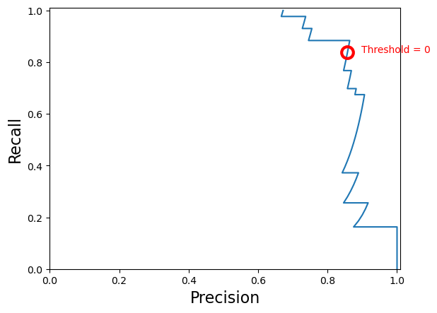

```python
# Lets import a function that computes precision, recall and threshold values for all the scores obtained for a certain
# classifier.

from sklearn.metrics import precision_recall_curve

# The function requires the true labels in y_test and the decision_function scores in y_scores_lr.
precision, recall, thresholds = precision_recall_curve(y_test, y_scores_lr)


# Lets find the threshold that is closest to 0

# Here is obtaining the abs values of all the thresholds and finding the index of the smallest (closes to zero) with
# the function np.argmin that returns the position of the smallest number (in this case all are positive
# numbers so it would be the closest to zero)
closest_zero = np.argmin(np.abs(thresholds))
closest_zero_p = precision[closest_zero]
closest_zero_r = recall[closest_zero]

# Lets graph the precision vs recall curve and lets show the point where the threshold was = 0
plt.figure()
plt.xlim([0.0, 1.01])
plt.ylim([0.0, 1.01])
# Plots the whole curve
plt.plot(precision, recall, label='Precision-Recall Curve')
# Plots the point where the threshold is = 0
plt.plot(closest_zero_p, closest_zero_r, 'o', markersize = 12, fillstyle = 'none', c='r', mew=3)
# Lets add some text indicating the value of threshold
plt.text(closest_zero_p+0.04, closest_zero_r, 'Threshold = 0', color='r')
plt.xlabel('Precision', fontsize=16)
plt.ylabel('Recall', fontsize=16)
plt.show()
```

### ROC curves, Area-Under-Curve (AUC)

As a result of obtaining the TPR and FPR values we can also compute the area under the curve (AUC).

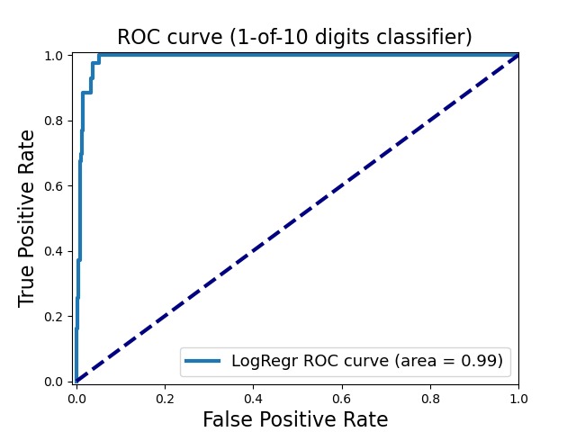

```python
from sklearn.metrics import roc_curve, auc

X_train, X_test, y_train, y_test = train_test_split(X, y_binary_imbalanced, random_state=0)

y_score_lr = lr.fit(X_train, y_train).decision_function(X_test)
fpr_lr, tpr_lr, _ = roc_curve(y_test, y_score_lr)
roc_auc_lr = auc(fpr_lr, tpr_lr)

plt.figure()
plt.xlim([-0.01, 1.00])
plt.ylim([-0.01, 1.01])
plt.plot(fpr_lr, tpr_lr, lw=3, label='LogRegr ROC curve (area = {:0.2f})'.format(roc_auc_lr))
plt.xlabel('False Positive Rate', fontsize=16)
plt.ylabel('True Positive Rate', fontsize=16)
plt.title('ROC curve (1-of-10 digits classifier)', fontsize=16)
plt.legend(loc='lower right', fontsize=13)
plt.plot([0, 1], [0, 1], color='navy', lw=3, linestyle='--')
plt.show()
```

```
gamma = 0.01  accuracy = 0.91   AUC = 1.00
gamma = 0.10  accuracy = 0.90   AUC = 0.98
gamma = 0.20  accuracy = 0.90   AUC = 0.66
gamma = 1.00  accuracy = 0.90   AUC = 0.50
```

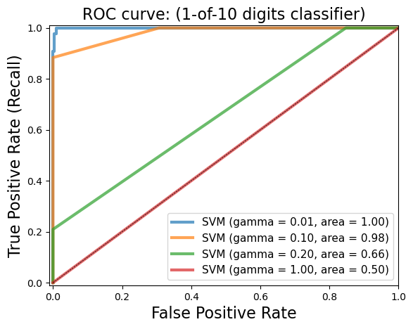

```python
# Lets graph different ROC curves for a SVC classifier but with different gamma values
# We will also compute the AUC for each curve

from sklearn.metrics import roc_curve, auc

X_train, X_test, y_train, y_test = train_test_split(X, y_binary_imbalanced, random_state=0)

# Lets graph different ROC curves where each has a different gamma value for a SVC classifier.


plt.figure()
plt.xlim([-0.01, 1.00])
plt.ylim([-0.01, 1.01])
# Iterates over different gamma values
for g in [0.01, 0.1, 0.20, 1]:
    svm = SVC(gamma=g).fit(X_train, y_train)
    y_score_svm = svm.decision_function(X_test)
    # Estimates false positive rates and true positive rates
    fpr_svm, tpr_svm, _ = roc_curve(y_test, y_score_svm)
    # Estimates the area under the curve
    roc_auc_svm = auc(fpr_svm, tpr_svm)
    # Estimates accuracy
    accuracy_svm = svm.score(X_test, y_test)
    # Plots the roc curves and labels each one with the value of gamma and AUC
    plt.plot(fpr_svm, tpr_svm, lw=3, alpha=0.7,
             label='SVM (gamma = {:0.2f}, area = {:0.2f})'.format(g, roc_auc_svm))
    # Prints the gamma value and the accuracy and AUC obtained for each in the screen
    print("gamma = {:.2f}  accuracy = {:.2f}   AUC = {:.2f}".format(g, accuracy_svm,
                                                                    roc_auc_svm))

# Defines general format of the plot
plt.xlabel('False Positive Rate', fontsize=16)
plt.ylabel('True Positive Rate (Recall)', fontsize=16)
plt.plot([0, 1], [0, 1], color='k', lw=0.5, linestyle='--')
plt.legend(loc="lower right", fontsize=11)
plt.title('ROC curve: (1-of-10 digits classifier)', fontsize=16)

plt.show()
```

We can see in the above graph that the value of gamma affects the decision boundaries, smaller gamma values result in better results, with better accuracies, TPR and AUC.

### Evaluation measures for multi-class classification

#### Multi-class confusion matrix

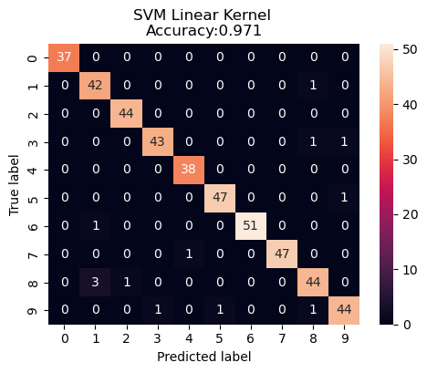

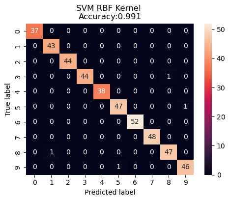

```python
dataset = load_digits()
X, y = dataset.data, dataset.target
X_train_mc, X_test_mc, y_train_mc, y_test_mc = train_test_split(X, y, random_state=0)


svm = SVC(kernel = 'linear').fit(X_train_mc, y_train_mc)
svm_predicted_mc = svm.predict(X_test_mc)
# Lets create the confusion matrix
confusion_mc = confusion_matrix(y_test_mc, svm_predicted_mc)

# Lets create a dataframe with the array provided in the confusion_mc
# We define the name of the columns and rows
df_cm = pd.DataFrame(confusion_mc,
                     index = [i for i in range(0,10)],
                     columns = [i for i in range(0,10)])

# Lets plot the confusion matrix with sns to also a apply a heatmap inside of it
plt.figure(figsize=(5.5,4))
sns.heatmap(df_cm, annot=True)
plt.title('SVM Linear Kernel \nAccuracy:{0:.3f}'.format(accuracy_score(y_test_mc,                                                                       svm_predicted_mc)))
plt.ylabel('True label')
plt.xlabel('Predicted label')


svm = SVC(kernel = 'rbf').fit(X_train_mc, y_train_mc)
svm_predicted_mc = svm.predict(X_test_mc)
confusion_mc = confusion_matrix(y_test_mc, svm_predicted_mc)
df_cm = pd.DataFrame(confusion_mc, index = [i for i in range(0,10)],
                  columns = [i for i in range(0,10)])

plt.figure(figsize = (5.5,4))
sns.heatmap(df_cm, annot=True)
plt.title('SVM RBF Kernel \nAccuracy:{0:.3f}'.format(accuracy_score(y_test_mc,
                                                                    svm_predicted_mc)))
plt.ylabel('True label')
plt.xlabel('Predicted label');
```

```python
confusion_mc
```

```
array([[37,  0,  0,  0,  0,  0,  0,  0,  0,  0],
       [ 0, 43,  0,  0,  0,  0,  0,  0,  0,  0],
       [ 0,  0, 44,  0,  0,  0,  0,  0,  0,  0],
       [ 0,  0,  0, 44,  0,  0,  0,  0,  1,  0],
       [ 0,  0,  0,  0, 38,  0,  0,  0,  0,  0],
       [ 0,  0,  0,  0,  0, 47,  0,  0,  0,  1],
       [ 0,  0,  0,  0,  0,  0, 52,  0,  0,  0],
       [ 0,  0,  0,  0,  0,  0,  0, 48,  0,  0],
       [ 0,  1,  0,  0,  0,  0,  0,  0, 47,  0],
       [ 0,  0,  0,  0,  0,  1,  0,  0,  0, 46]], dtype=int64)
```

#### Multi-class classification report

```python
print(classification_report(y_test_mc, svm_predicted_mc))
```

```
              precision    recall  f1-score   support

           0       1.00      1.00      1.00        37
           1       0.98      1.00      0.99        43
           2       1.00      1.00      1.00        44
           3       1.00      0.98      0.99        45
           4       1.00      1.00      1.00        38
           5       0.98      0.98      0.98        48
           6       1.00      1.00      1.00        52
           7       1.00      1.00      1.00        48
           8       0.98      0.98      0.98        48
           9       0.98      0.98      0.98        47

    accuracy                           0.99       450
   macro avg       0.99      0.99      0.99       450
weighted avg       0.99      0.99      0.99       450
```

#### Micro- vs. macro-averaged metrics

Micro and macro average can be computed to each metric evaluator: recall, precision, f1-score, etc.

Micro: Each instance has equal weight, so the number of instances in each class is considered.

Macro: Each class has equal weight, so the number of instances in each class is not considered.

```python
# Lets compute micro and macro averages for recall

print('Micro-averaged recall = {:.2f} (treat instances equally)'
      .format(recall_score(y_test_mc, svm_predicted_mc, average = 'micro')))
print('Macro-averaged recall = {:.2f} (treat classes equally)'
      .format(recall_score(y_test_mc, svm_predicted_mc, average = 'macro')))
```

```
Micro-averaged recall = 0.99 (treat instances equally)
Macro-averaged recall = 0.99 (treat classes equally)
```

```python
# Lets compute micro and macro averages for precision

print('Micro-averaged precision = {:.2f} (treat instances equally)'
      .format(precision_score(y_test_mc, svm_predicted_mc, average = 'micro')))
print('Macro-averaged precision = {:.2f} (treat classes equally)'
      .format(precision_score(y_test_mc, svm_predicted_mc, average = 'macro')))
```

```
Micro-averaged precision = 0.99 (treat instances equally)
Macro-averaged precision = 0.99 (treat classes equally)
```

```python
# Lets compute micro and macro averages for f1-score

print('Micro-averaged f1 = {:.2f} (treat instances equally)'
      .format(f1_score(y_test_mc, svm_predicted_mc, average = 'micro')))
print('Macro-averaged f1 = {:.2f} (treat classes equally)'
      .format(f1_score(y_test_mc, svm_predicted_mc, average = 'macro')))
```

```
Micro-averaged f1 = 0.99 (treat instances equally)
Macro-averaged f1 = 0.99 (treat classes equally)
```

### Regression evaluation metrics

This an evaluation method for regression classifiers

There are other metrics available such us:

- mean_absolute_error
- mean_squared_error
- median_absolute_error (more robust when outlayers are present in the data)

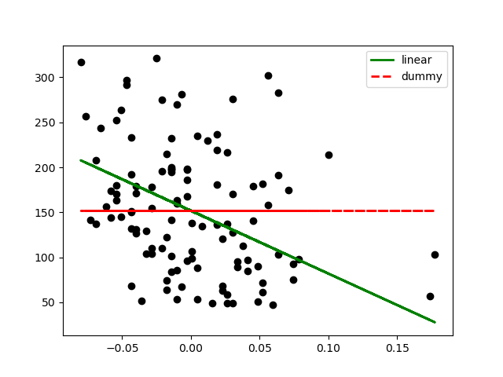

```
Linear model, coefficients:  [-698.80206267]
Mean squared error (dummy): 4965.13
Mean squared error (linear model): 4646.74
r2_score (dummy): -0.00
r2_score (linear model): 0.06
```

```python
%matplotlib notebook
import matplotlib.pyplot as plt
import numpy as np
from sklearn.model_selection import train_test_split
from sklearn import datasets
from sklearn.linear_model import LinearRegression
from sklearn.metrics import mean_squared_error, r2_score
from sklearn.dummy import DummyRegressor

diabetes = datasets.load_diabetes()

X = diabetes.data[:, None, 6]
y = diabetes.target

X_train, X_test, y_train, y_test = train_test_split(X, y, random_state=0)

# Lets create a linear regressor and make predictions
lm = LinearRegression().fit(X_train, y_train)
y_predict = lm.predict(X_test)

# Lets create a dummy regressor and make predictions
lm_dummy_mean = DummyRegressor(strategy = 'mean').fit(X_train, y_train)
y_predict_dummy_mean = lm_dummy_mean.predict(X_test)

# Plot outputs
#Plot data
plt.scatter(X_test, y_test,  color='black')
# Plot the linear regresor predictions
plt.plot(X_test, y_predict, color='green', linewidth=2, label='linear')
# Plot the dummy regresor predictions
plt.plot(X_test, y_predict_dummy_mean, color='red', linestyle = 'dashed',
         linewidth=2, label = 'dummy')
plt.legend()
plt.show()

print('Linear model, coefficients: ', lm.coef_)
print("Mean squared error (dummy): {:.2f}".format(mean_squared_error(y_test,
                                                                     y_predict_dummy_mean)))
print("Mean squared error (linear model): {:.2f}".format(mean_squared_error(y_test, y_predict)))
print("r2_score (dummy): {:.2f}".format(r2_score(y_test, y_predict_dummy_mean)))
print("r2_score (linear model): {:.2f}".format(r2_score(y_test, y_predict)))
```

### Model selection using evaluation metrics

#### Cross-validation example

```python
from sklearn.model_selection import cross_val_score
from sklearn.svm import SVC

# lets load dataset
dataset = load_digits()

# Lets create variables and classes
# again, making this a binary problem with 'digit 1' as positive class
# and 'not 1' as negative class with a boolean mask
X, y = dataset.data, dataset.target == 1

# Creates a SVC clasifier with linear Kernel
clf = SVC(kernel='linear', C=1)

# Lets use cross validation to obtain different evaluation metrics for the SVC classifierwe created above:

# 1- accuracy is the default scoring metric.
# If we don´t specify the metric, accuracy is the default one
print('Cross-validation (accuracy)', cross_val_score(clf, X, y, cv=5))

# By adding the parameter "scoring =" we can select different metrics
# 2- use Area under the curve (AUC) as scoring metric
print('Cross-validation (AUC)', cross_val_score(clf, X, y, cv=5, scoring = 'roc_auc'))

# 3- use recall as scoring metric
print('Cross-validation (recall)', cross_val_score(clf, X, y, cv=5, scoring = 'recall'))


# 4- use precision as scoring metric
print('Cross-validation (precision)', cross_val_score(clf, X, y, cv=5, scoring = 'precision'))

## IMPORTANT ## HERE WE ARE NOT DOING ANY PARAMETER TUNNING !
# We are just analyzing the performance of the model along multiple K-folds (cv)
```

```
Cross-validation (accuracy) [0.91944444 0.98611111 0.97214485 0.97493036 0.96935933]
Cross-validation (AUC) [0.9641871  0.9976571  0.99372205 0.99699002 0.98675611]
Cross-validation (recall) [0.81081081 0.89189189 0.83333333 0.83333333 0.83333333]
Cross-validation (precision) [0.57692308 0.97058824 0.88235294 0.90909091 0.85714286]
```

#### Grid search example

This will test several hyperparameters (grid of values) for a given classifier, and will output the best value (or combination of values if we test several hyperparameters) for a chosen metric.

```python
from sklearn.svm import SVC
from sklearn.model_selection import GridSearchCV
from sklearn.metrics import roc_auc_score

# Loads dataset, divide into features / labels and train/test sets.
dataset = load_digits()
X, y = dataset.data, dataset.target == 1
X_train, X_test, y_train, y_test = train_test_split(X, y, random_state=0)

# Create the classifier we want to evaluate
clf = SVC(kernel='rbf')

# We want to evaluate how different hyperparameters modify the efectiveness of the model
# We must pass predefined values for hyperparameters to the GridSearchCV function.
# We do this by defining a dictionary in which we mention a particular hyperparameter along with the values it can take.
# Here we choose the hyperparameter 'gamma' with different values:
# example fo grid_values = {'parameter': [list of values for the parameter]}
# it is to use several hyperparameter with several values each, that would be a grid of parameters
grid_values = {'gamma': [0.001, 0.01, 0.05, 0.1, 1, 10, 100]}

# Example of grid_values with several hyperparameters.
# grid search will try all the possible combinations and return the best one for the chosen metric
grid_values2 = {'kernel':['linear','rbf'], 'gamma': [0.001, 0.01, 0.05, 0.1, 1, 10, 100]}


## 1- Lets find the best hyperparameters for the default metric: Accuracy
# Creates a GridSearchCV class object definig the classifier and the grid of hyperparameters to test
grid_clf_acc = GridSearchCV(clf, param_grid = grid_values)
# Run fit with all sets of parameters.
grid_clf_acc.fit(X_train, y_train)

# We can see which are the parameters that obtained the best score for the metric, in this case, accuracy
best_parameters = grid_clf_acc.best_params_
# We can see the best value obtained for the accuracy
best_score_ = grid_clf_acc.best_score_

print('Grid best parameter (max. accuracy): ', best_parameters)
print('Grid best score (accuracy): ', best_score_)

## 2- Lets try another evaluation metric: AUC
# We will use the same grid_values with different gamma values in it
grid_clf_auc = GridSearchCV(clf, param_grid = grid_values, scoring = 'roc_auc')
grid_clf_auc.fit(X_train, y_train)
y_decision_fn_scores_auc = grid_clf_auc.decision_function(X_test)

print('Test set AUC: ', roc_auc_score(y_test, y_decision_fn_scores_auc))
print('Grid best parameter (max. AUC): ', grid_clf_auc.best_params_)
print('Grid best score (AUC): ', grid_clf_auc.best_score_)

# As a result we can the wich hyperparameters provided the best evaluation metric results
```

```
Grid best parameter (max. accuracy):  {'gamma': 0.001}
Grid best score (accuracy):  0.9985157648354676
Test set AUC:  0.99982858122393
Grid best parameter (max. AUC):  {'gamma': 0.001}
Grid best score (AUC):  1.0
```

```python
# We can also make a report

# print best parameter after tuning
print(grid_clf_auc.best_params_)
grid_predictions = grid_clf_auc.predict(X_test)

# print classification report
print(classification_report(y_test, grid_predictions, target_names=['0', '1']))
```

```
{'gamma': 0.001}
              precision    recall  f1-score   support

           0       1.00      1.00      1.00       407
           1       1.00      0.98      0.99        43

    accuracy                           1.00       450
   macro avg       1.00      0.99      0.99       450
weighted avg       1.00      1.00      1.00       450
```

#### Evaluation metrics supported for model selection

```python
# Here we can see a list of all the available metrics to use in GridSearchCV (and cross validation)

from sklearn.metrics.scorer import SCORERS

print(sorted(list(SCORERS.keys())))
```

[output not shown]